# Sexism and Affirmative Action preferences

Study 2

Ago Echeverri

2026-05-07

## Study 1: Motivation

- Does sexism influence redistribution/redistribution policy preferences?
- Psychology uses batteries that are nowadays suceptible to partisan spillover effects.
- Study 1: ultimatum game (in a vacuum, does sexism influence redistribution preferences?)

## Study 1: “Results”

- HS predicts higher minimum acceptable offers from female proposers
- BS predicts lower minimum acceptable offers (paternalistic protection logic)
- HS × BS interaction: attenuation effect, but still negative tendency

## Reminding questions

- External validity: real-life redistribution takes more complex shapes (AA Policy)
- Individual scale vs. group scale: are people able to pick up on redistributive costs at the big scale?
- How permanent are the effects of HS? Are they constant, or do they activate under threat?

## Study 2

- Twofold goal:
  1. Retest effects of sexism in redistribution preferences on real-life settings
  2. Test if threat activation effects are amplified via sexism
- Scenario: Women in STEM

## Women Are Gaining Ground

- In 2022, women earned **58%** of all U.S. bachelor’s degrees
- **65.3%** of female high school completers enrolled in college vs. **57.6%** of males
- At MIT: acceptance rate **5.6%** for women vs. **3.1%** for men in 2022
- Female applicants are **1.8x more likely** to be admitted

## Threat and Hostile Sexism

- Previous research finds that Hostile Sexism is activated under group threat (Glick & Fiske 2001, Rudman & Fairchild 2004), and react with backlash
- Status threat gets activated against real or prospective lost of the upper echelon (Craig & Richeson 2014)

## SDO and Hostile Sexism

- This mechanism is very similar to Social Dominance Orientation (Rios Morrison et al. 2009).
- I posit that HS should still have an effect after control.

## Design

- Sample of 1000 American men
- Pre-treatment:
- PID-7 and Lib-Con-5
- ASI-7 and SDO-s (random order)
- Mock Vignette check
- Treatment: https://agoecheverri.github.io/exp2.html

## Design

- **Factual manipulation checks:**
  - *Which sex composes the majority of college enrollees in the United States?* (Men / Women / They are approximately equal)
  - *Compared to men, women at selective universities like MIT and Caltech are how many times more likely to be admitted?* (About the same / 1.5 times more likely / Twice as likely / Three times as likely)
- Additional Demographic: Do you have any family member who currently benefitted from any of these programs?

## Hypotheses

**H1:** Gender status threat will increase opposition to gender-based affirmative action.

**H2:** Opposition will be greater when the affirmative action beneficiary is a woman than a man.

**H3:** Hostile Sexism will moderate the effect of gender status threat on opposition to affirmative action.

**H4:** Among men high in HS, opposition will be greater toward gender-based than class-based affirmative action.

## Outcomes

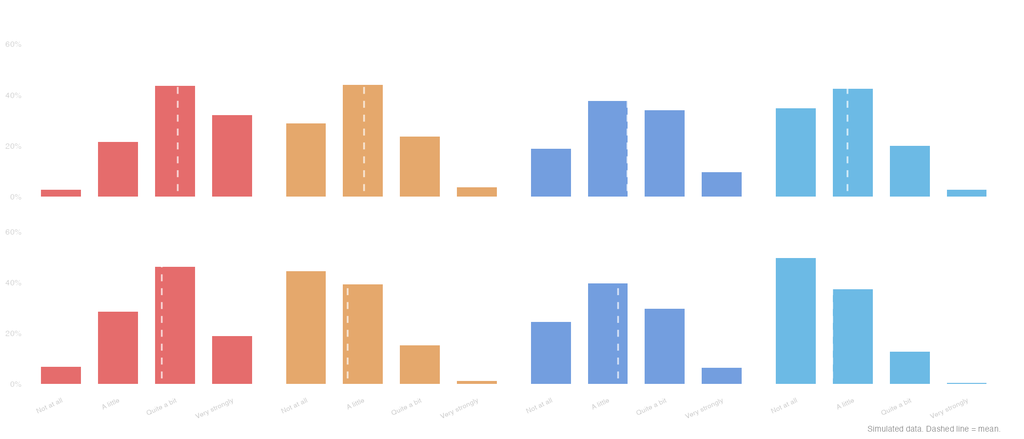